# 2015-2020 Yılları Arasında Marmara Bölgesindeki 4 İlde(Bursa-Balıkesir-Çanakkale-Yalova) Dağıtılan Enerji

```python
#2015-2020 yılları arasında Marmara bölgesindeki 4 ilde dağıtılan toplam enerji verisi(MWh) kullanılmıştır.

#1. Adım: Gerekli Kütüphanelerin Yüklenmesi
import pandas as pd
import numpy as np
import matplotlib.pyplot as plt
from datetime import datetime, date
import datetime
import seaborn as sns
```

```python
#2. Adım: Verinin yüklenmesi
data = pd.read_excel(r'D:\Users\200142\Desktop\TEZ\Data\dagitilan_data2.xlsx')

data.info()

data['datetime'] = pd.to_datetime(data['datetime'], format= '%Y-%m-%d %H:%M:%S')
data
```

```
<class 'pandas.core.frame.DataFrame'>
RangeIndex: 53352 entries, 0 to 53351
Data columns (total 3 columns):
 #   Column     Non-Null Count  Dtype
---  ------     --------------  -----
 0   datetime   53352 non-null  datetime64[ns]
 1   dagitilan  53352 non-null  float64
 2   sicaklik   53352 non-null  int64
dtypes: datetime64[ns](1), float64(1), int64(1)
memory usage: 1.2 MB
```

|  | datetime | dagitilan | sicaklik |
| --- | --- | --- | --- |
| 0 | 2015-01-01 00:00:00.000 | 936.403640 | 4 |
| 1 | 2015-01-01 01:00:00.000 | 865.697698 | 4 |
| 2 | 2015-01-01 02:00:00.000 | 787.724599 | 3 |
| 3 | 2015-01-01 03:00:00.000 | 729.666069 | 3 |
| 4 | 2015-01-01 04:00:00.000 | 688.746319 | 4 |
| ... | ... | ... | ... |
| 53347 | 2021-01-31 18:59:59.989 | 1581.656962 | 10 |
| 53348 | 2021-01-31 19:59:59.989 | 1519.676780 | 10 |
| 53349 | 2021-01-31 20:59:59.989 | 1452.169556 | 10 |
| 53350 | 2021-01-31 21:59:59.989 | 1419.980267 | 10 |
| 53351 | 2021-01-31 22:59:59.989 | 1387.801731 | 10 |

53352 rows × 3 columns

**Veri zaman serisi verisinden oluşmakta olup, saatlik tüketilen enerji değerlerini içermektedir. Görüldüğü gibi 'tarih', 'dagitilan', 'sicaklik' isimlerinde olan 3 kolondan ve 53.352 satırdan oluşmaktadır ve boş değer içermemektedir. Kolonlardaki veri formatları datetime64, float64 ve int64'tür.

```python
#3. Adım: Aykırı/Uç Değerleri Tespit Etme
data.describe().T
```

|  | count | mean | std | min | 25% | 50% | 75% | max |
| --- | --- | --- | --- | --- | --- | --- | --- | --- |
| dagitilan | 53352.0 | 1395.188785 | 287.337661 | -6.5136 | 1157.77997 | 1397.27312 | 1604.760906 | 2253.161139 |
| sicaklik | 53352.0 | 15.576192 | 8.716975 | -12.0000 | 9.00000 | 16.00000 | 22.000000 | 40.000000 |

|  | datetime | dagitilan | sicaklik |
| --- | --- | --- | --- |
| 2091 | 2015-03-29 03:00:00.000 | -6.513600 | 11 |
| 10827 | 2016-03-27 02:59:59.998 | -0.057150 | 3 |
| 2147 | 2015-03-31 11:00:00.000 | 4.352364 | 14 |
| 2148 | 2015-03-31 12:00:00.000 | 15.426765 | 14 |
| 2149 | 2015-03-31 13:00:00.000 | 15.853416 | 14 |
| 2150 | 2015-03-31 14:00:00.000 | 98.527724 | 14 |
| 2151 | 2015-03-31 15:00:00.000 | 200.043716 | 14 |
| 2152 | 2015-03-31 16:00:00.000 | 380.273709 | 15 |
| 2153 | 2015-03-31 17:00:00.000 | 453.224399 | 15 |
| 2154 | 2015-03-31 18:00:00.000 | 565.357782 | 14 |

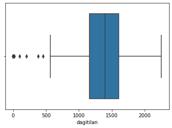

```python
_= sns.boxplot(x=data['dagitilan'])
data.sort_values(['dagitilan'], ascending=True).head(10)
```

**Veride negatif değerler bulunmaktadır. Ayrıca boxplot grafiği incelenirse; Q1, Q2 ve Q3 değerlerinin sırasıyla 1000-1500, 1500-2000 değerleri arasında hesaplandığı, alt sınır değerinin altında değerlerin olduğu görülmektedir.

```python
#**Quartile (Kartiller) ve IQR ile Aykırı Değer Tespiti

Q1 = data.dagitilan.quantile(0.25)
Q2 = data.dagitilan.quantile(0.5)
Q3 = data.dagitilan.quantile(0.75)
Q4 = data.dagitilan.quantile(1)
IQR = Q3 - Q1

print("Q1-->", Q1)
print("Q2-->", Q2)
print("Q3-->", Q3)
print("Q4-->", Q4)
print("IQR-->", IQR)
print("Alt sınır: Q1 - 1.5 * IQR--->", Q1 - 1.5 * IQR)
print("Üst sınır: Q3 + 1.5 * IQR--->", Q3 + 1.5 * IQR)

data[data.dagitilan < Q1 - 1.5 * IQR].sort_values('dagitilan')
data.sort_values(['dagitilan'], ascending=True).head(20)

data.loc[(data['dagitilan'] < Q1 - 1.5 * IQR ), 'dagitilan'] = Q1 - 1.5 * IQR
data.sort_values(['dagitilan'], ascending=True).head(10)
```

```
Q1--> 1157.7799699944999
Q2--> 1397.2731202595
Q3--> 1604.7609064212502
Q4--> 2253.161139442
IQR--> 446.9809364267503
Alt sınır: Q1 - 1.5 * IQR---> 487.3085653543744
Üst sınır: Q3 + 1.5 * IQR---> 2275.2323110613756
```

|  | datetime | dagitilan | sicaklik |
| --- | --- | --- | --- |
| 2149 | 2015-03-31 13:00:00.000 | 487.308565 | 14 |
| 2091 | 2015-03-29 03:00:00.000 | 487.308565 | 11 |
| 10827 | 2016-03-27 02:59:59.998 | 487.308565 | 3 |
| 2153 | 2015-03-31 17:00:00.000 | 487.308565 | 15 |
| 2152 | 2015-03-31 16:00:00.000 | 487.308565 | 15 |
| 2151 | 2015-03-31 15:00:00.000 | 487.308565 | 14 |
| 2150 | 2015-03-31 14:00:00.000 | 487.308565 | 14 |
| 2148 | 2015-03-31 12:00:00.000 | 487.308565 | 14 |
| 2147 | 2015-03-31 11:00:00.000 | 487.308565 | 14 |
| 2154 | 2015-03-31 18:00:00.000 | 565.357782 | 14 |

**Verinin Q1, Q2, Q3 değerleri bulunduktan sonra Interquartile range (IQR — Çeyrekler açıklığı) hesaplanır. IQR, birinci çeyrek Q1 ve üçüncü çeyrek Q3 arasındaki uzaklıktır. IQR kullanılarak alt ve üst sınır değerleri aşağıdaki gibi hesaplanır.

IQR = (Q3 – Q1)

Alt Sınır Değer (ASD)= Q1–1.5(IQR)

Üst Sınır Değer (ÜSD)= Q3 + 1.5(IQR)

ASD ve ÜSD dışında kalan tüm değerler outlier (aykırı değer) olarak tespit edilir.

ASD = 487.30 ÜSD = 2275.23

**Grafikte de görüleceği üzere alt sınır değerinin altında olan değerler mevcuttur. Bu değerlere ait günler incelendiğinde 31 Mart 2015 tarihinde Ülke genelinde kesinti olduğu bilgisine ulaşılmıştır. ASD altındaki tüm değerler ASD'ne eşitlenmiştir.

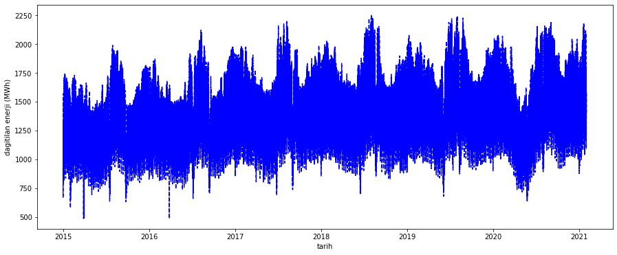

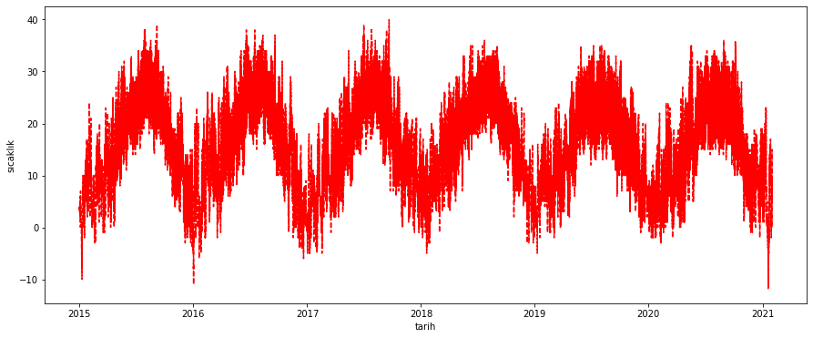

```python
#Son 6 senenin enerji tüketimi
plt.figure(figsize=(15,6))
plt.plot(data.datetime,data.dagitilan, 'b--')
plt.xlabel('tarih')
plt.ylabel('dagitilan enerji (MWh)')
plt.show()

#Son 6 senenin hava sıcaklığı
plt.figure(figsize=(15,6))
plt.plot(data.datetime,data.sicaklik, 'r--')
plt.xlabel('tarih')
plt.ylabel('sıcaklık')
plt.show()
```

```python
#Adım 4: Yeni Öznitelikler Oluşturma
#Yükün farklı saatlerde, günlerde, haftalarda ve sıcaklıklardaki değişiminin incelenebilmesi için eldeki verilerden yeni özellikler çıkarılır.


def create_features(df, label = None, label2= None):

    df.index = df.datetime
    df = df.copy()
    df['date'] = df.index
    df['date'] = pd.to_datetime(df.date, format='%Y-%m-%d', errors= 'ignore')
    df['hour'] = df['date'].dt.hour
    df['dayofweek'] = df['date'].dt.dayofweek
    df['quarter'] = df['date'].dt.quarter
    df['month'] = df['date'].dt.month
    df['year'] = df['date'].dt.year
    df['dayofyear'] = df['date'].dt.dayofyear
    df['dayofmonth'] = df['date'].dt.day
    df['weekofyear'] = df['date'].dt.weekofyear
    df['day_name']=df['date'].dt.day_name()
    df['sicaklik'] = df['sicaklik']
    df['is_weekend'] = np.where(df['day_name'].isin(['Sunday', 'Saturday']), 1,0)
    df["ix"] = range(0,len(df))
    df["movave_30"] = df.dagitilan.rolling(30).agg([np.mean])
    df["movave_90"] = df.dagitilan.rolling(90).agg([np.mean])
    df["movave_365"] = df.dagitilan.rolling(365).agg([np.mean])

    X = df[['hour','date', 'dayofweek', 'quarter', 'month', 'year', 'dayofyear', 'dayofmonth',
            'weekofyear','day_name', 'is_weekend','ix', 'sicaklik',
            'movave_30','movave_90','movave_365']]

    if label:
        y = df[label]
        return X, y
    return X


X, y = create_features(data, label='dagitilan', label2 = 'sicaklik')


new_featuresdf = pd.concat([X, y], axis=1)
new_featuresdf.info()
```

```
<class 'pandas.core.frame.DataFrame'>
DatetimeIndex: 53352 entries, 2015-01-01 00:00:00 to 2021-01-31 22:59:59.989000
Data columns (total 17 columns):
 #   Column      Non-Null Count  Dtype
---  ------      --------------  -----
 0   hour        53352 non-null  int64
 1   date        53352 non-null  datetime64[ns]
 2   dayofweek   53352 non-null  int64
 3   quarter     53352 non-null  int64
 4   month       53352 non-null  int64
 5   year        53352 non-null  int64
 6   dayofyear   53352 non-null  int64
 7   dayofmonth  53352 non-null  int64
 8   weekofyear  53352 non-null  int64
 9   day_name    53352 non-null  object
 10  is_weekend  53352 non-null  int32
 11  ix          53352 non-null  int32
 12  sicaklik    53352 non-null  int64
 13  movave_30   53323 non-null  float64
 14  movave_90   53263 non-null  float64
 15  movave_365  52988 non-null  float64
 16  dagitilan   53352 non-null  float64
dtypes: datetime64[ns](1), float64(4), int32(2), int64(9), object(1)
memory usage: 6.9+ MB
```

```python
new_featuresdf.tail(3)
```

| datetime | hour | date | dayofweek | quarter | month | year | dayofyear | dayofmonth | weekofyear | day_name | is_weekend | ix | sicaklik | movave_30 | movave_90 | movave_365 | dagitilan |
| --- | --- | --- | --- | --- | --- | --- | --- | --- | --- | --- | --- | --- | --- | --- | --- | --- | --- |
| 2021-01-31 20:59:59.989 | 20 | 2021-01-31 20:59:59.989 | 6 | 1 | 1 | 2021 | 31 | 31 | 4 | Sunday | 1 | 53349 | 10 | 1406.950792 | 1577.491268 | 1591.800594 | 1452.169556 |
| 2021-01-31 21:59:59.989 | 21 | 2021-01-31 21:59:59.989 | 6 | 1 | 1 | 2021 | 31 | 31 | 4 | Sunday | 1 | 53350 | 10 | 1396.728495 | 1579.646753 | 1590.957623 | 1419.980267 |
| 2021-01-31 22:59:59.989 | 22 | 2021-01-31 22:59:59.989 | 6 | 1 | 1 | 2021 | 31 | 31 | 4 | Sunday | 1 | 53351 | 10 | 1386.715458 | 1581.313645 | 1589.947244 | 1387.801731 |

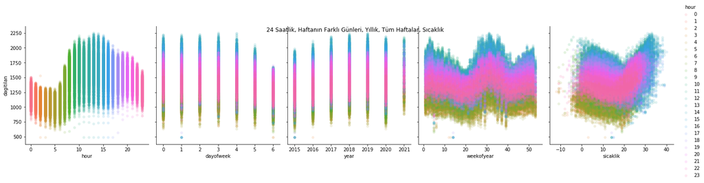

```python
sns.pairplot(new_featuresdf.dropna(), hue='hour',
             x_vars = ['hour', 'dayofweek','year', 'weekofyear', 'sicaklik'],
             y_vars = ['dagitilan'],
             height = 4,
             plot_kws = {'alpha' : 0.15, 'linewidth' : 0})

plt.suptitle('24 Saatlik, Haftanın Farklı Günleri, Yıllık, Tüm Haftalar, Sıcaklık')
plt.show()
```

**Grafikte elektrik tüketiminin 24 saatlik, 1 haftalık ve yıl toplamlarının profili ve tüketim-sıcaklık ilişkisi verilmiştir.

Grafikler incelendiğinde gün içerisinde saat 10:00-15:00 arasında yükün maksimuma ulaştığı,

1 haftalık profilden hafta ortalarında yükün arttığı,

2020'ye kadar tüketimin hep arttığı, 2020 yılında düşüş olduğu,

Yıllık profilden ise mevsimselliğin etkisi görülebilmektedir.

Ayrıca sıcaklık değişimine bağlı olarak, çok soğuk/sıcak olması halinde tüketimin artışı görülmektedir.

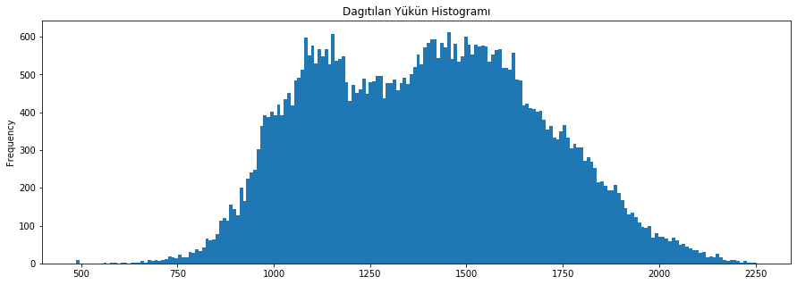

```python
_ = new_featuresdf['dagitilan'].plot.hist(figsize=(15, 5), bins=200, title='Dagıtılan Yükün Histogramı')
```

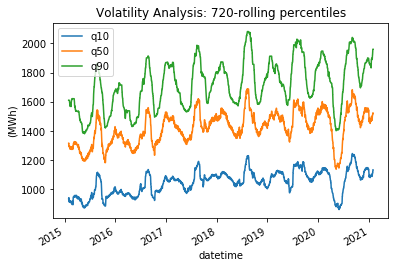

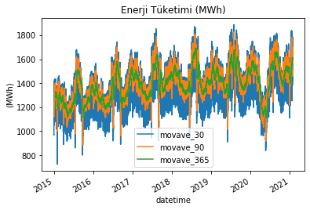

```python
#Adım 4. Mevsimsellik ve Trend Tespiti

new_featuresdf.groupby(new_featuresdf.index.year).mean().T #yıllık ortalama
new_featuresdf.resample(rule="MS").mean().T  #aylık ortalama

data_rolling = new_featuresdf.dagitilan.rolling(window=720) #aylık toplam saat sayısı
new_featuresdf['q10'] = data_rolling.quantile(0.1).to_frame("q10")
new_featuresdf['q50'] = data_rolling.quantile(0.5).to_frame("q50")
new_featuresdf['q90'] = data_rolling.quantile(0.9).to_frame("q90")

new_featuresdf.q10.head(500)

new_featuresdf[["q10", "q50", "q90"]].plot(title="Volatility Analysis: 720-rolling percentiles")
plt.ylabel("(MWh)")
plt.show()


plt.figure(figsize=(15,6))
new_featuresdf[[ "movave_30", "movave_90", "movave_365"]].plot(title="Enerji Tüketimi (MWh)")
plt.ylabel("(MWh)")
plt.show()
```

**Trend: zaman serilerinde uzun vadede gösterilen kararlı durumdur. Veri incelendiğinde yıl içerisinde sezonlara göre dalgalanmaların mevcut olduğunu görülür.

Ayrıca diğer yıllardan farklı olarak 2020 yılında pandemi etkisinden kaynaklanan tüketim düşüşü göze çarpmaktadır.

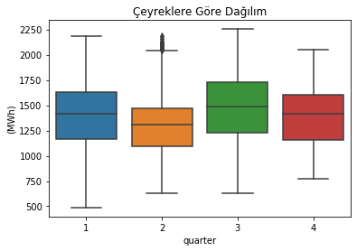

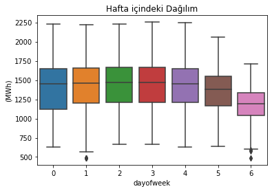

```python
sns.boxplot(data=new_featuresdf, x='quarter', y="dagitilan")
plt.title("Çeyreklere Göre Dağılım")
plt.ylabel("(MWh)")
plt.show()

sns.boxplot(data=new_featuresdf, x="dayofweek", y="dagitilan")
plt.title("Hafta içindeki Dağılım")
plt.ylabel("(MWh)")
plt.show()
```

**Zaman serisinin belirli bir davranışı belirli periyotlarla tekrar etmesi durumuna mevsimsellik denir. İncelenen grafiklerden veride mevsimsellik bulunduğu açıkça görülmektedir. Zaman serilerinde durağanlık zaman içerisinde varyansın ve ortalamanın sabit olmasıdır. Verinin 0.1-0.5-0.9'luk çeyreklikleri için 720 saatlik durağanlık analizi yapıldığında volatilitesinin kısa vadede (çeyrek ve ay) değiştiği, uzun vadede daha kararlı yapıda olduğu yorumu yapılabilir.

Yılın 3. çeyreğinde tüketimin maksimuma ulaştığı ve en düşük tüketimlerin 2. çeyrekte olduğu,

2020 yılına kadar yıl ortalama tüketiminin sürekli arttığı,

Yıllık ortalama tüketimin en çok 2019 yılında olduğu,

2020 yılında pandemi etkisiyle birlikte ortalama tüketimin düşüşü,

Hafta içi çarşamba gününün diğer günlere göre ortalama tüketimin daha yüksek olduğu,

Değişkenliğin en az pazar gününde yaşandığı görülebilmektedir.

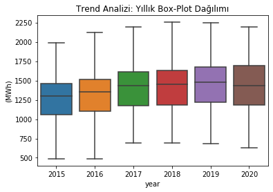

```python
sns.boxplot(data=new_featuresdf["2015":"2020"], x="year", y="dagitilan")
plt.title("Trend Analizi: Yıllık Box-Plot Dağılımı")
plt.ylabel("(MWh)")
plt.show()
```

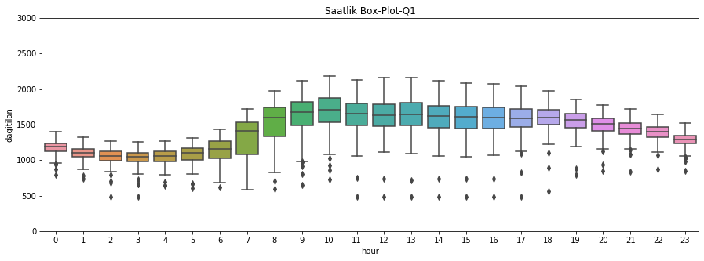

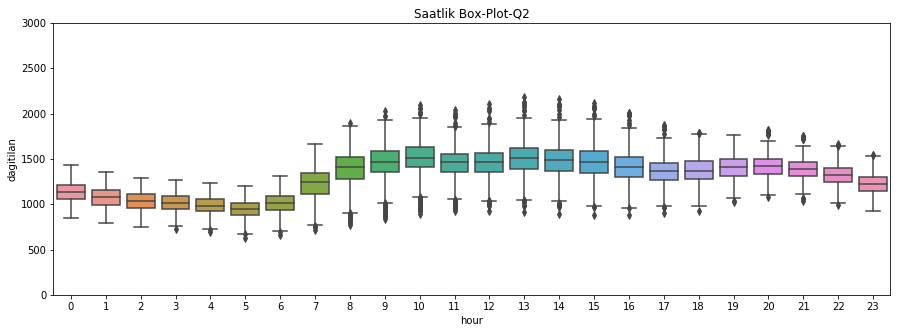

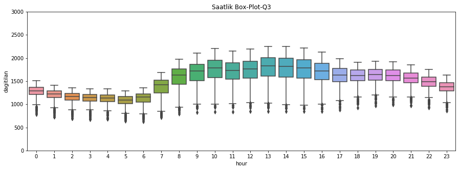

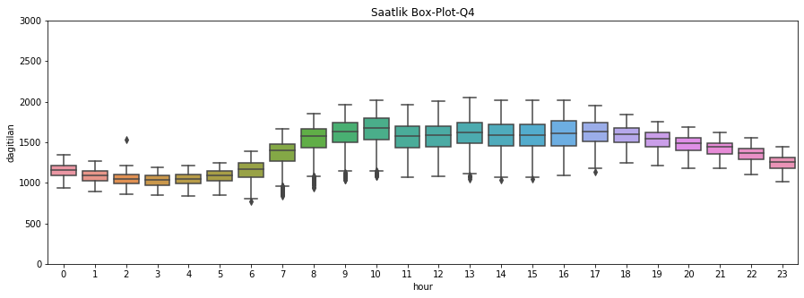

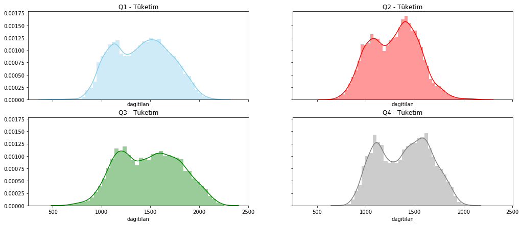

```python
#Çeyreklerdeki Tüketim Profili
fig, ax = plt.subplots(figsize=(15,5))
sns.boxplot(new_featuresdf.loc[new_featuresdf['quarter']==1].hour, new_featuresdf.loc[new_featuresdf['quarter']==1].dagitilan)
ax.set_title('Saatlik Box-Plot-Q1')
ax.set_ylim(0,3000)
fig, ax = plt.subplots(figsize=(15,5))
sns.boxplot(new_featuresdf.loc[new_featuresdf['quarter']==2].hour, new_featuresdf.loc[new_featuresdf['quarter']==2].dagitilan)
ax.set_title('Saatlik Box-Plot-Q2')
ax.set_ylim(0,3000)
fig, ax = plt.subplots(figsize=(15,5))
sns.boxplot(new_featuresdf.loc[new_featuresdf['quarter']==3].hour, new_featuresdf.loc[new_featuresdf['quarter']==3].dagitilan)
ax.set_title('Saatlik Box-Plot-Q3')
ax.set_ylim(0,3000)
fig, ax = plt.subplots(figsize=(15,5))
sns.boxplot(new_featuresdf.loc[new_featuresdf['quarter']==4].hour, new_featuresdf.loc[new_featuresdf['quarter']==4].dagitilan)
ax.set_title('Saatlik Box-Plot-Q4')
_ = ax.set_ylim(0,3000)


Q1 = new_featuresdf[new_featuresdf["quarter"]==1]
Q2 = new_featuresdf[new_featuresdf["quarter"]==2]
Q3 = new_featuresdf[new_featuresdf["quarter"]==3]
Q4 = new_featuresdf[new_featuresdf["quarter"]==4]

fig,axes = plt.subplots(2,2,figsize=(17,7),sharex=True,sharey=True)

sns.distplot(Q1["dagitilan"],color="skyblue", ax=axes[0,0]).set_title("Q1 - Tüketim")
sns.distplot(Q2["dagitilan"],color="red", ax=axes[0,1]).set_title("Q2 - Tüketim")
sns.distplot(Q3["dagitilan"],color="green", ax=axes[1,0]).set_title("Q3 - Tüketim")
sns.distplot(Q4["dagitilan"],color="gray", ax=axes[1,1]).set_title("Q4 - Tüketim")
del Q1, Q2, Q3, Q4
```

**Yılın çeyreklerindeki(Q1-Q2-Q3-Q4) profil,trend ve dağılım birbirinden farklıdır. Çeyreklerden Q3 diğer üçünden oldukça farklıdır. Bunun en çok bilinen sebebi mevsimsellik olmakla birlikte başka nedenler de kaynaklanıyor olabilir.

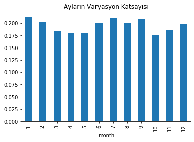

```python
new_featuresdf.groupby("month")["dagitilan"].std().divide(new_featuresdf.groupby("month")["dagitilan"].mean()).plot(kind="bar")
plt.title("Ayların Varyasyon Katsayısı")
plt.show()
```

Varyasyon katsayısı = std sapma / ortama

VK Ana kütlelerin ortalamaları büyüklük olarak birbirinden çok farklı ise karşılaştırma için kullanılmaktadır. VK değeri küçük olan serilerin diğerlerine göre daha az değişken olduğu söylenir ve sırasıyla Ekim-Nisan-Mayıs aylarında değişkenliğin en az olduğu grafikten görülmektedir.

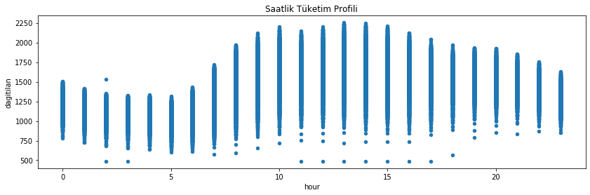

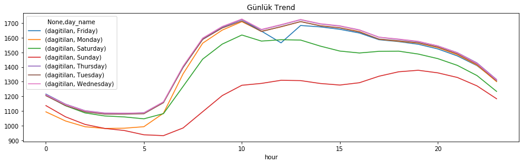

```python
_ = new_featuresdf[['dagitilan', 'hour']].plot(x='hour',
                                 y='dagitilan',
                                 kind='scatter',
                                 figsize=(14,4),
                                 title=('Saatlik Tüketim Profili'))

daily_trends = new_featuresdf.pivot_table(index=['hour'],
                               columns=['day_name'],
                               values=['dagitilan'],
                               aggfunc = 'mean' ).plot(figsize=(15,4), title='Günlük Trend')
```

Günlük trende bakıldığında;

Salı-Çarşamba-Perşembe günlerinin profillerinin çok benzer olduğu,

Pazartesi gününün ilk saatlerinde tüketimin bu 3 günden daha düşük başladığı fakat saat 10'a doğru onları yakaladığı,

Cuma günlerinde hafta içi diğer günlere göre 11-14 aralığında düşüşün yaşandığı,

Cumartesi ve pazar günlerinin hafta içinden daha düşük tüketimde ve birbirlerinden farklı profillerde olduğu sonucuna varılmaktadır.

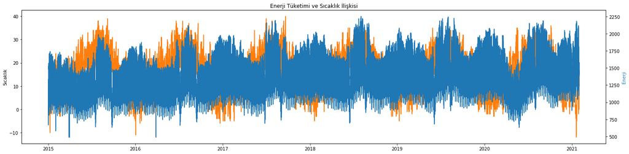

```python
#Tüketim-Sıcaklık İlişkisi
fig, ax1 = plt.subplots(figsize = (20,5))
ax1.plot(new_featuresdf.date, new_featuresdf.sicaklik, color = 'tab:orange')
ax1.set_ylabel('Sıcaklık')
ax2 = ax1.twinx()
ax2.plot(new_featuresdf.date,new_featuresdf.dagitilan,color = 'tab:blue')
ax2.set_ylabel('Enerji',color = 'tab:blue')
plt.title('Enerji Tüketimi ve Sıcaklık İlişkisi')
fig.tight_layout()
plt.show()
```

Enerji tüketimi ile sıcaklık arasındaki ilişki incelendiğinde, birinin zirvelerini gördüğü yerlerde diğerinde çukurlaşmalar görülebilmektedir. Bu durum düşük sıcaklıkta ısıtıcı kullanımıyla oluşan enerji tüketiminin artmasından kaynaklanmaktadır. Yüksek sıcaklıklarda ise sıcaklık artışıyla birlikte sogutucu kullanımından kaynaklanan tüketim artışı görülmektedir.